# StockMarketEDA

##### 'Moving Average - MA'

A moving average (MA) is a widely used indicator in technical analysis that helps smooth out price action by filtering out the “noise” from random price fluctuations. It is a trend-following, or lagging, indicator because it is based on past prices.

```python
## Lets go ahead and p[lot out several moving averages
ma_day = [10,20,50]

for ma in ma_day:
    col_name = "MA for %s days" %(str(ma))
    AAPL[col_name] = pd.DataFrame.rolling(AAPL['close'],ma).mean()
```

```python
AAPL.head(50)
```

| date | open | high | low | close | volume | MA for 10 days | MA for 20 days | MA for 50 days |
| --- | --- | --- | --- | --- | --- | --- | --- | --- |
| 2022-01-19 | 170.000 | 171.080 | 165.940 | 166.23 | 94814990 | NaN | NaN | NaN |
| 2022-01-20 | 166.980 | 169.680 | 164.180 | 164.51 | 91420515 | NaN | NaN | NaN |
| 2022-01-21 | 164.415 | 166.330 | 162.300 | 162.41 | 122848858 | NaN | NaN | NaN |
| 2022-01-24 | 160.020 | 162.300 | 154.700 | 161.62 | 162706686 | NaN | NaN | NaN |
| 2022-01-25 | 158.980 | 162.760 | 157.020 | 159.78 | 115798367 | NaN | NaN | NaN |
| 2022-01-26 | 163.500 | 164.389 | 157.820 | 159.69 | 108275308 | NaN | NaN | NaN |
| 2022-01-27 | 162.450 | 163.840 | 158.280 | 159.22 | 121954638 | NaN | NaN | NaN |
| 2022-01-28 | 165.710 | 170.350 | 162.800 | 170.33 | 179935660 | NaN | NaN | NaN |
| 2022-01-31 | 170.160 | 175.000 | 169.510 | 174.78 | 115541590 | NaN | NaN | NaN |
| 2022-02-01 | 174.010 | 174.840 | 172.310 | 174.61 | 86213911 | 165.318 | NaN | NaN |
| 2022-02-02 | 174.745 | 175.880 | 173.330 | 175.84 | 84914256 | 166.279 | NaN | NaN |
| 2022-02-03 | 174.480 | 176.240 | 172.120 | 172.90 | 89418074 | 167.118 | NaN | NaN |
| 2022-02-04 | 171.680 | 174.100 | 170.680 | 172.39 | 82465400 | 168.116 | NaN | NaN |
| 2022-02-07 | 172.860 | 173.946 | 170.950 | 171.66 | 77251204 | 169.120 | NaN | NaN |
| 2022-02-08 | 171.730 | 175.350 | 171.430 | 174.83 | 74829217 | 170.625 | NaN | NaN |
| 2022-02-09 | 176.050 | 176.650 | 174.900 | 176.28 | 71285038 | 172.284 | NaN | NaN |
| 2022-02-10 | 174.140 | 175.480 | 171.550 | 172.12 | 90865899 | 173.574 | NaN | NaN |
| 2022-02-11 | 172.330 | 173.080 | 168.040 | 168.64 | 98670687 | 173.405 | NaN | NaN |
| 2022-02-14 | 167.370 | 169.580 | 166.560 | 168.88 | 86185530 | 172.815 | NaN | NaN |
| 2022-02-15 | 170.970 | 172.950 | 170.250 | 172.79 | 64286320 | 172.633 | 168.9755 | NaN |
| 2022-02-16 | 171.850 | 173.340 | 170.050 | 172.55 | 61177398 | 172.304 | 169.2915 | NaN |
| 2022-02-17 | 171.030 | 171.910 | 168.470 | 168.88 | 69589344 | 171.902 | 169.5100 | NaN |
| 2022-02-18 | 169.820 | 170.541 | 166.190 | 167.30 | 82772674 | 171.393 | 169.7545 | NaN |
| 2022-02-22 | 164.980 | 166.690 | 162.150 | 164.32 | 91162758 | 170.659 | 169.8895 | NaN |
| 2022-02-23 | 165.540 | 166.150 | 159.750 | 160.07 | 90009247 | 169.183 | 169.9040 | NaN |
| 2022-02-24 | 152.580 | 162.850 | 152.000 | 162.74 | 141147540 | 167.829 | 170.0565 | NaN |
| 2022-02-25 | 163.840 | 165.120 | 160.874 | 164.85 | 91974222 | 167.102 | 170.3380 | NaN |
| 2022-02-28 | 163.060 | 165.420 | 162.430 | 165.12 | 95056629 | 166.750 | 170.0775 | NaN |
| 2022-03-01 | 164.695 | 166.600 | 161.970 | 163.20 | 83474425 | 166.182 | 169.4985 | NaN |
| 2022-03-02 | 164.390 | 167.360 | 162.950 | 166.56 | 79724750 | 165.559 | 169.0960 | NaN |
| 2022-03-03 | 168.470 | 168.910 | 165.550 | 166.23 | 76678441 | 164.927 | 168.6155 | NaN |
| 2022-03-04 | 164.490 | 165.550 | 162.100 | 163.17 | 83819592 | 164.356 | 168.1290 | NaN |
| 2022-03-07 | 163.360 | 165.020 | 159.040 | 159.30 | 96418845 | 163.556 | 167.4745 | NaN |
| 2022-03-08 | 158.820 | 162.880 | 155.800 | 157.44 | 131148280 | 162.868 | 166.7635 | NaN |
| 2022-03-09 | 161.475 | 163.410 | 159.410 | 162.95 | 91454905 | 163.156 | 166.1695 | NaN |
| 2022-03-10 | 160.200 | 160.390 | 155.980 | 158.52 | 105342033 | 162.734 | 165.2815 | NaN |
| 2022-03-11 | 158.930 | 159.280 | 154.500 | 154.73 | 96970102 | 161.722 | 164.4120 | NaN |
| 2022-03-14 | 151.450 | 154.120 | 150.100 | 150.62 | 108732111 | 160.272 | 163.5110 | NaN |
| 2022-03-15 | 150.900 | 155.570 | 150.380 | 155.09 | 92964302 | 159.461 | 162.8215 | NaN |
| 2022-03-16 | 157.050 | 160.000 | 154.460 | 159.59 | 102300157 | 158.764 | 162.1615 | NaN |
| 2022-03-17 | 158.610 | 161.000 | 157.630 | 160.62 | 75615376 | 158.203 | 161.5650 | NaN |
| 2022-03-18 | 160.510 | 164.480 | 159.760 | 163.98 | 123511692 | 158.284 | 161.3200 | NaN |
| 2022-03-21 | 163.510 | 166.350 | 163.015 | 165.38 | 95811352 | 158.892 | 161.2240 | NaN |
| 2022-03-22 | 165.510 | 169.420 | 164.910 | 168.82 | 81532007 | 160.030 | 161.4490 | NaN |
| 2022-03-23 | 167.990 | 172.640 | 167.650 | 170.21 | 98062674 | 160.756 | 161.9560 | NaN |
| 2022-03-24 | 171.060 | 174.140 | 170.210 | 174.07 | 90131418 | 162.311 | 162.5225 | NaN |
| 2022-03-25 | 173.880 | 175.280 | 172.750 | 174.72 | 80546156 | 164.310 | 163.0160 | NaN |
| 2022-03-28 | 172.170 | 175.730 | 172.000 | 175.60 | 90371916 | 166.808 | 163.5400 | NaN |
| 2022-03-29 | 176.690 | 179.010 | 176.340 | 178.96 | 100589440 | 169.195 | 164.3280 | NaN |
| 2022-03-30 | 178.550 | 179.610 | 176.700 | 177.77 | 92633154 | 171.013 | 164.8885 | 166.6574 |

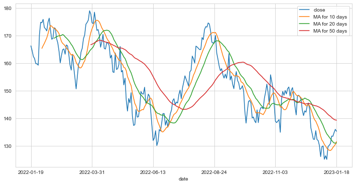

```python
AAPL[['close','MA for 10 days','MA for 20 days','MA for 50 days']].plot(subplots = False,figsize = (12,6))
plt.show()
```

#### Daily Return Analysis

Now that we've done some baseline analysis, let's go ahead and dive a little deeper. We're now going to analyze the risk of the stock. In order to do so we'll need to take a closer look at the daily changes of the stock, and not just its absolute value. Let's go ahead and use pandas to retrieve the daily returns for the Apple stock.

```python
# use pct_change to find the percent change for each day
AAPL['Daily Return'] = AAPL['close'].pct_change()
```

```python
AAPL.head()
```

| date | open | high | low | close | volume | MA for 10 days | MA for 20 days | MA for 50 days | Daily Return |
| --- | --- | --- | --- | --- | --- | --- | --- | --- | --- |
| 2022-01-19 | 170.000 | 171.08 | 165.94 | 166.23 | 94814990 | NaN | NaN | NaN | NaN |
| 2022-01-20 | 166.980 | 169.68 | 164.18 | 164.51 | 91420515 | NaN | NaN | NaN | -0.010347 |
| 2022-01-21 | 164.415 | 166.33 | 162.30 | 162.41 | 122848858 | NaN | NaN | NaN | -0.012765 |
| 2022-01-24 | 160.020 | 162.30 | 154.70 | 161.62 | 162706686 | NaN | NaN | NaN | -0.004864 |
| 2022-01-25 | 158.980 | 162.76 | 157.02 | 159.78 | 115798367 | NaN | NaN | NaN | -0.011385 |

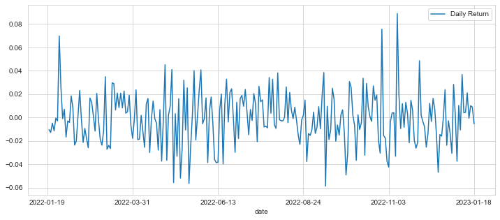

```python
AAPL['Daily Return'].plot(figsize=(12,5),legend = True)
plt.show()
```

Now let's get an overall look at the average daily return using a histogram. We'll use seaborn to create both a histogram and kde plot on the same figure.

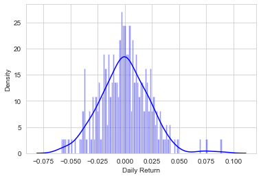

```python
sns.distplot(AAPL['Daily Return'].dropna(),bins = 100,color='blue')
plt.show()
```

Now want to analyze the returns of all the stocks in our list. Let's go ahead and build a DataFrame with all the ['close'] columns for each of the stocks dataframes.

```python
closing_df1 = pd.DataFrame(AAPL['close'])
close1 = closing_df1.rename(columns = {"close": "AAPL_close"})

closing_df2 = pd.DataFrame(GOOG['close'])
close2 = closing_df2.rename(columns = {"close": "GOOG_close"})

closing_df3 = pd.DataFrame(MSFT['close'])
close3 = closing_df3.rename(columns = {"close": "MSFT_close"})

closing_df4 = pd.DataFrame(AMZN['close'])
close4 = closing_df4.rename(columns = {"close": "AMZN_close"})

closing_df = pd.concat([close1,close2,close3,close4],axis = 1)
closing_df.head()
```

| date | AAPL_close | GOOG_close | MSFT_close | AMZN_close |
| --- | --- | --- | --- | --- |
| 2022-01-19 | 166.23 | 135.6520 | 303.33 | 156.299 |
| 2022-01-20 | 164.51 | 133.5065 | 301.60 | 151.668 |
| 2022-01-21 | 162.41 | 130.0920 | 296.03 | 142.643 |
| 2022-01-24 | 161.62 | 130.3720 | 296.37 | 144.544 |
| 2022-01-25 | 159.78 | 126.7355 | 288.49 | 139.986 |

## Now that we have all the closing prices, let's go ahead and get the daily return for all the stocks.

```python
# Make a new tech returns DataFrame
tech_returns = closing_df.pct_change()
```

Now we can compare the daily percentage return of two stocks to check how correlated. First let's see a sotck compared to itself.

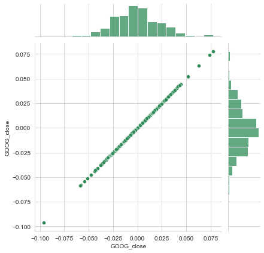

```python
# Comparing Google to itself should show a perfectly linear relationship
sns.jointplot('GOOG_close','GOOG_close',tech_returns,kind='scatter',color = 'seagreen')
plt.show()
```

So now we can see that if two stocks are perfectly (and positivley) correlated with each other a linear relationship bewteen its daily return values should occur. So let's go ahead and compare Google and Microsoft the same way.

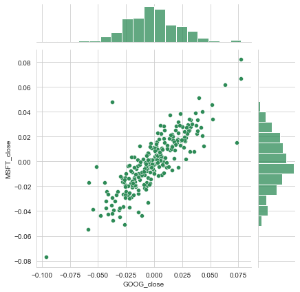

```python
sns.jointplot('GOOG_close','MSFT_close',tech_returns,kind='scatter',color = 'seagreen')
plt.show()
```

Python's Seaborn and pandas packages make it very easy to repeat this comparison analysis for every possible combination of stocks in our technology stock ticker list. We can use sns.pairplot() to automatically create this plot.

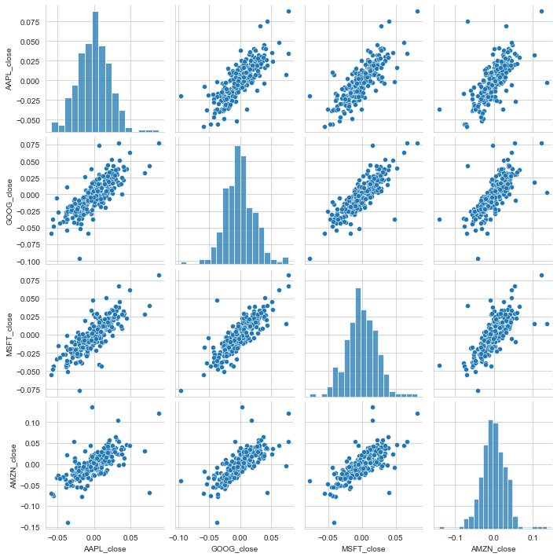

```python
sns.pairplot(tech_returns.dropna())
plt.show()
```

Finally, we could also do a correlation plot, to get actual numerical values for the correlation between the stocks' daily return values.

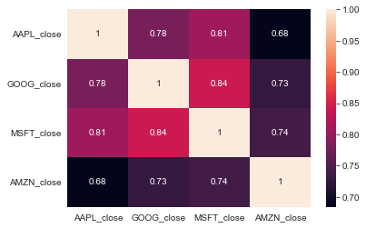

```python
corr = tech_returns.dropna().corr()

sns.heatmap(corr,annot = True)
plt.show()
```